# README

[figure not shown]

Last Coffee Logo

# Motivation:

Our motivation behind this project stems from our comprehensive experience as students. Currently, there are no mobile applications or online platforms that completely integrate both the aspects of individual and communal learning. For instance, Luminus currently has assignment and quiz datelines available on its portal, however, to view their schedule, students have to access another website, NUSMods, to view their timetable. As students ourselves, we know the difficulty of sourcing for a student planner that can function as both a tracker and a scheduler.

We believe what students hope to gain from their academic journey is not only good academic grades but also the opportunity to network and engage with other individuals of similar hobbies, courses and interests. In view of the COVID-19 pandemic, we have also realized that the current cohort of students that entered university have toned-down university experiences because of the reduction in face-to-face lessons as well as physical classes. Most lessons have also been changed to online lessons in order to facilitate the learning of individuals during a lockdown. Thus, chances for interaction and networking are greatly reduced, even more so for students who do not stay on campus.

With all these limitations in mind, we have decided to create our very own interactive platform that addresses these limitations.

# Aim:

Our goal for our Orbital project is to allow students to have an all-in-one study application that encompasses the various aspects of their education journey and experience. Therefore, we propose to create a platform for students to not only track and monitor their academic progress, but also one that enriches their education journey by connecting them with like-minded students who wish to study and interact with others, expanding their social circle as they pursue their degrees.

# How Are We Different From Existing Platforms?

### 1) LumiNUS

LumiNUS is a website for NUS students to access the modules they are taking/have taken, to check deadlines for assignments and quizzes and submit assignments, just to name a few. Our application is different from LumiNUS as we will only incorporate its deadline feature by allowing students to have a calendar view of his/her academic year/semester. Thus, we will not be completely replacing LumiNUS as LumiNUS serves as a platform for not only NUS students but professors and staff that allow them to receive a student’s assignment submission, etc.

### 2) NUSMods

NUSMods allows students to search for different modules, choose different modules and finally plan their own timetable for each week of the semester. Our application will include the timetable feature that displays the timing and task required to be done, thus providing not only a calendar view but also a daily task view.

### 3) Housetutors.sg

Housetutors.sg is a website that allows for the pairing of private tutors and parents based on various requirements and conditions. This greatly reduces the need for man-power to specifically allocate and pair a parent to a tutor just for their child. In our application, we hope to implement a similar system/algorithm for our platform to do the same pairing and matching for students through recommendations on the platform page but based on similar interests, modules, timetable, etc.

## Tech Stack:

1. React.js
2. HTML
3. CSS
4. JavaScript
5. Firebase
6. Redux

# User Stories:

1. As a student who has to plan his/her own timetable and schedule every start of the semester, I want to be able to optimize this process and reduce the time spent on planning my schedule by having a comprehensive app that encompasses all features.
2. As a student who wants to track his/her academic progress, I want to be able to consistently remind myself and have a comprehensive view of all my datelines as well as important details/notes at a glance.
3. As a student who wants to network and find like-minded friends during his/her education, I would like to have more outlets and avenues for interaction and communication with other students.

# Scope of Project:

### There are 4 parts of our Orbital Project: Setup, Core, Extensions and Testing.

Setup - User Registration, Login and Home Page

Core - Profile, Calendar, To-do List, Study Buddy, History and About Us Page

Extensions - Study Buddy Search, Notifications Panel, etc.

Testing - NIL

## Milestone 1: Setup - User Registration and Login

1. Frontend Web Routing: Set up routing for our website from the Login page to the Home page.
2. Backend API Endpoints & Database: Set up backend API endpoints and a database for user registration and login.

## Milestone 2: Core - Profile, Calendar, To-do List, Study Buddy, History and About Us Page

## Milestone 3: Extensions & Testing

# Proposed Core Features:

Your Ultimate Study Web Application: “The Last Coffee”

1. We will have a User Interface Web Application that is easily accessible for everyone, where students can create an account with us. This app provides a means to add classes, assignments and events, just to name a few, to their calendar.
2. Login Page: For new users to sign up with us through google or for existing users to log into their accounts
3. Home Page: This page functions similar to a LinkedIn’s or Instagram’s Home page, where students can view the activities of their buddies, peers and friends and see their progress.
4. “My Profile” Page: This page is for the users to update their personal information and customize their profile for others to view.
5. “My Calendar” Page: A calendar page to show the past, present and future events that have been created by the user.
6. “To-do List” Page: This page will present the to-do list for the user on the current day itself.
7. “Study Buddies” Page: This page is where users can connect with other peers and friends and add them as their own study buddy!
8. “My History” Page: This page displays all past events, deadlines and tasks that have been completed by the user.
9. “About Us” Page: A page displaying information about the creators and developers of this application: Zen and Hau Xiang, at the same time showing our group poster and motivation for the project.
10. “Contact Us” Page: Provides a possible platform and avenue for users to interact with the developers to point out flaws or areas of improvement for this web application so as to further improve the application.

# Development Timeline:

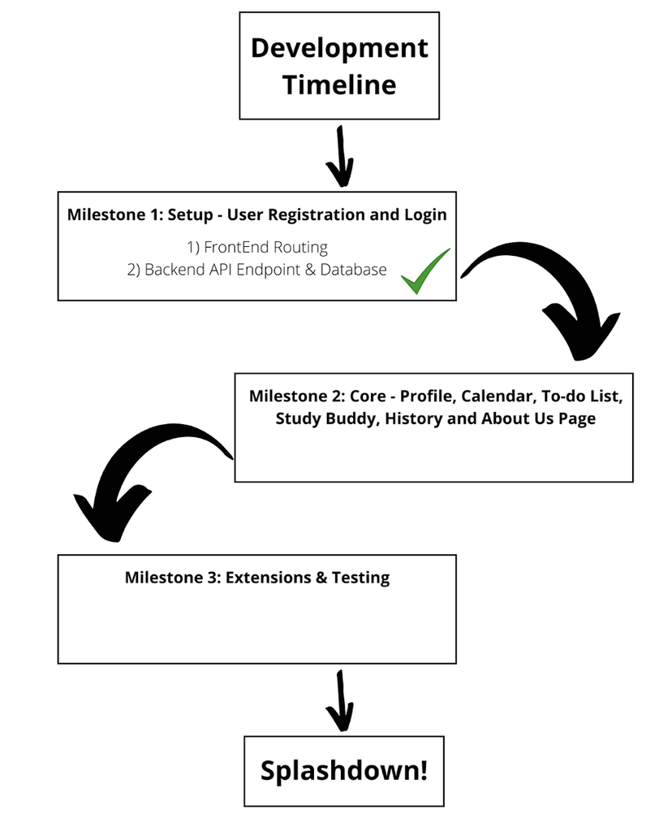

Our Development Timeline